# Analysis and visualization of Flavobacterium abundance

### August 1, 2016

The input data from these analyses were generated from a sampling of copepods and water as explained in Bontrager et. al 2016. All data processing was accomplished via scripts publicly available at github.com/mbontrager/16S_processing.

The input file for this analysis is the `sample_matrix_raw_counts.csv` file generated from the `01_pre-processing` step in the 16S processing analysis workflow. That input is a data frame of all bacterial OTUs in the sampling, the greengenes taxonomy associated with the OTU, and the raw count of sequences from each OTU in each sample. First, we want to quickly see the prevalence of flavobacterium, aeromonas, and chryseobacterium in paired water “W” and Eurytemora affinis “E” samples:

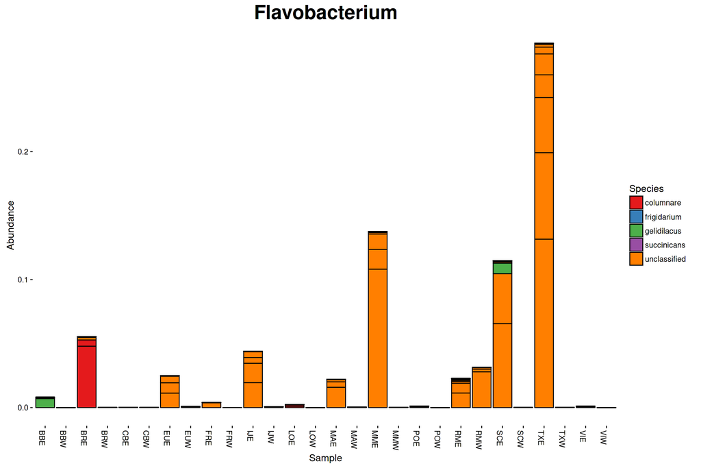

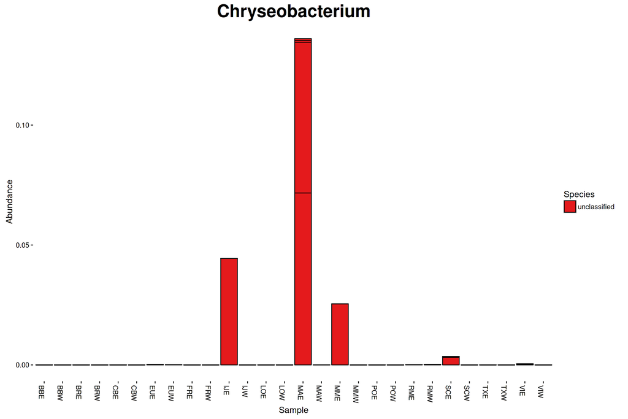

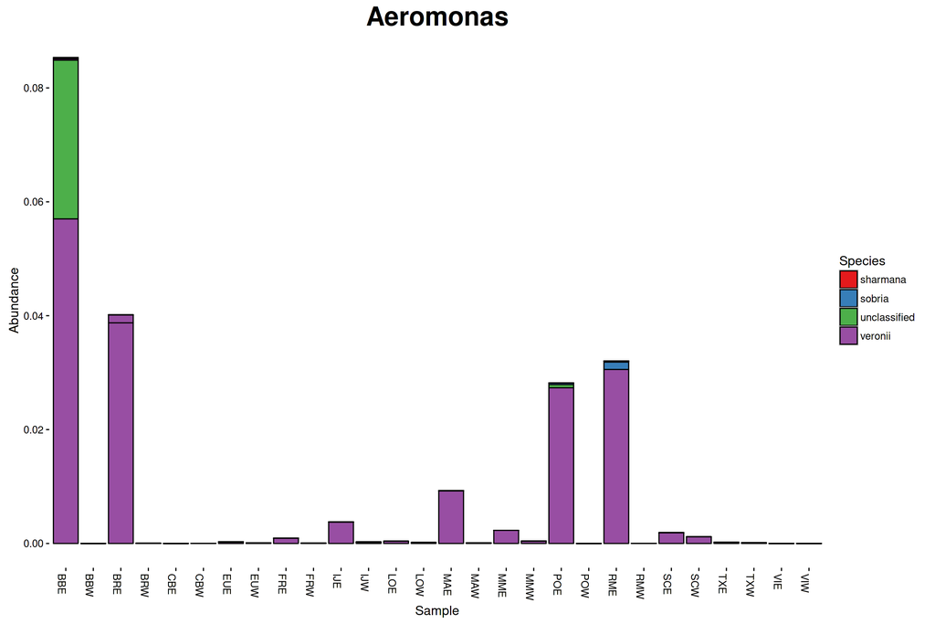

We can quantify the enrichment with a Wald test, available in the DESeq2 package. This method is taken from McMurdie and Holmes (2014) and from phyloseq tutorials available at http://joey711.github.io/phyloseq-extensions/DESeq2.html

The following table is a list of bacterial genera which are significantly enriched in copepod-associated samples. Note the significant enrichment of aeromonas, flavobacterium, and chryseobacterium:

```
## [1] '1.12.3'
```

```
## [1] "Genera that are more abundant in copepods:"
```

|  | baseMean | log2FoldChange | lfcSE | stat | pvalue | padj | Kingdom | Phylum | Class | Order | Family | Genus |
| --- | --- | --- | --- | --- | --- | --- | --- | --- | --- | --- | --- | --- |
| 8667 | 202.390645 | -8.636575 | 1.1115207 | -7.770053 | 0.0000000 | 0.0000000 | Bacteria | Bacteroidetes | Saprospirae | Saprospirales | Saprospiraceae | unclassified |
| 3760 | 116.676678 | -8.099930 | 1.3426335 | -6.032867 | 0.0000000 | 0.0000000 | Bacteria | Proteobacteria | Betaproteobacteria | Burkholderiales | Comamonadaceae | Rubrivivax |
| 7405 | 149.050431 | -5.896205 | 0.9922232 | -5.942418 | 0.0000000 | 0.0000000 | Bacteria | Bacteroidetes | Cytophagia | Cytophagales | Cytophagaceae | Leadbetterella |
| 2828 | 128.430749 | -5.275551 | 0.9671217 | -5.454899 | 0.0000000 | 0.0000004 | Bacteria | Proteobacteria | Gammaproteobacteria | Aeromonadales | Aeromonadaceae | Aeromonas |
| 3942 | 260.358187 | -4.759589 | 0.9150258 | -5.201590 | 0.0000002 | 0.0000015 | Bacteria | Bacteroidetes | Flavobacteriia | Flavobacteriales | Flavobacteriaceae | Flavobacterium |
| 8417 | 21.292402 | -4.386033 | 0.8875940 | -4.941486 | 0.0000008 | 0.0000055 | Bacteria | Proteobacteria | Gammaproteobacteria | Alteromonadales | Shewanellaceae | Shewanella |
| 2970 | 3.131963 | -5.221930 | 1.1694173 | -4.465412 | 0.0000080 | 0.0000445 | Bacteria | Actinobacteria | Actinobacteria | Actinomycetales | Corynebacteriaceae | Corynebacterium |
| 8170 | 187.491238 | -4.297981 | 0.9698107 | -4.431774 | 0.0000093 | 0.0000513 | Bacteria | Proteobacteria | Gammaproteobacteria | Pseudomonadales | Pseudomonadaceae | Pseudomonas |
| 8718 | 10.979252 | -3.750081 | 0.8522792 | -4.400061 | 0.0000108 | 0.0000579 | Bacteria | Proteobacteria | Betaproteobacteria | Burkholderiales | Comamonadaceae | Delftia |
| 1114 | 210.082533 | -4.646792 | 1.0628532 | -4.371998 | 0.0000123 | 0.0000643 | Bacteria | Proteobacteria | Gammaproteobacteria | Alteromonadales | Chromatiaceae | Rheinheimera |
| 2070 | 1.921940 | -4.426645 | 1.0613341 | -4.170831 | 0.0000303 | 0.0001411 | Bacteria | Actinobacteria | Actinobacteria | Actinomycetales | Micrococcaceae | Renibacterium |
| 8461 | 14.757180 | -6.437576 | 1.5522935 | -4.147138 | 0.0000337 | 0.0001548 | Bacteria | Bacteroidetes | Flavobacteriia | Flavobacteriales | Weeksellaceae | Chryseobacterium |
| 6707 | 18.369566 | -5.056017 | 1.2593878 | -4.014663 | 0.0000595 | 0.0002596 | Bacteria | Proteobacteria | Betaproteobacteria | Neisseriales | Neisseriaceae | unclassified |
| 8363 | 32.328309 | -3.042396 | 0.7591903 | -4.007422 | 0.0000614 | 0.0002645 | Bacteria | GN02 | BD1-5 | unclassified | unclassified | unclassified |
| 3250 | 5.709301 | -3.234051 | 0.8248372 | -3.920835 | 0.0000882 | 0.0003624 | Bacteria | Proteobacteria | Gammaproteobacteria | Xanthomonadales | Xanthomonadaceae | Stenotrophomonas |
| 4417 | 2135.393549 | -4.480607 | 1.1516991 | -3.890432 | 0.0001001 | 0.0004070 | Bacteria | Proteobacteria | Betaproteobacteria | Burkholderiales | Comamonadaceae | Polaromonas |
| 7408 | 11.035991 | -4.323869 | 1.1378324 | -3.800093 | 0.0001446 | 0.0005665 | Bacteria | Verrucomicrobia | Verrucomicrobiae | Verrucomicrobiales | Verrucomicrobiaceae | unclassified |
| 9078 | 492.931172 | -3.842931 | 1.0225751 | -3.758092 | 0.0001712 | 0.0006584 | Bacteria | Proteobacteria | unclassified | unclassified | unclassified | unclassified |
| 3661 | 7.087307 | -5.205313 | 1.4137319 | -3.681966 | 0.0002314 | 0.0008513 | Bacteria | Cyanobacteria | Chloroplast | Chlorophyta | Chlamydomonadaceae | unclassified |
| 6969 | 3.095252 | -3.334231 | 0.9441057 | -3.531629 | 0.0004130 | 0.0014559 | Bacteria | Proteobacteria | Gammaproteobacteria | Oceanospirillales | Halomonadaceae | Halomonas |
| 916 | 56.817002 | -4.498080 | 1.3222569 | -3.401820 | 0.0006694 | 0.0023209 | Bacteria | Proteobacteria | Betaproteobacteria | Burkholderiales | Oxalobacteraceae | unclassified |
| 1122 | 6.307024 | -5.342666 | 1.7580550 | -3.038964 | 0.0023739 | 0.0073836 | Bacteria | Proteobacteria | Gammaproteobacteria | Vibrionales | Vibrionaceae | Enterovibrio |
| 4721 | 2.759229 | -2.794012 | 0.9249522 | -3.020710 | 0.0025218 | 0.0077864 | Bacteria | Proteobacteria | Alphaproteobacteria | Rhizobiales | Bradyrhizobiaceae | unclassified |

## Abundance overall

I’d like to visualize this relationship overall in a stacked bar chart. So what I need to know is the mean % abundance of aeromonas, flavobacterium, and chryseobacterium in copepods vs. water samples overall:

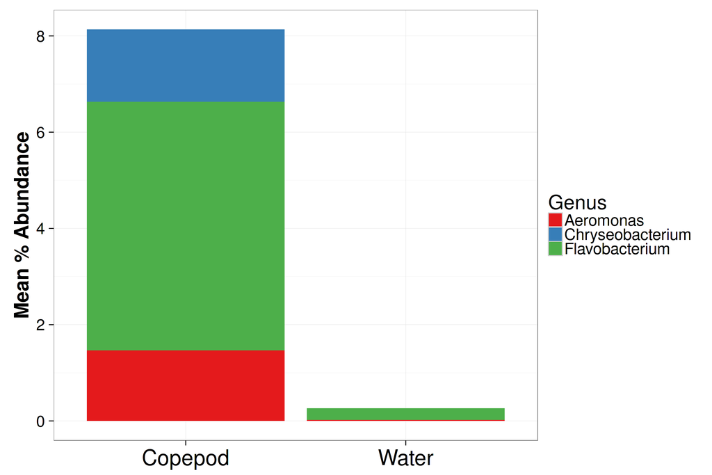

## Copepod microbiome vs water

Overall, prospective fish pathogens composed approximately 8.13% of Copepod microbiomes and only 0.26% of water microbiomes.